# How many colours are in each national flag?

Tejas Kale

2026-09-12

Wikipedia publishes a [list of sovereign states](https://en.wikipedia.org/wiki/List_of_sovereign_states) together with each country’s flag. This notebook scrapes that list, downloads a PNG thumbnail of every flag, then asks three vision models on [OpenRouter](https://openrouter.ai) to look at the pictures:

1. **Google Gemini 3.5 Flash Lite** (`google/gemini-3.5-flash-lite`) counts the distinct colours and names them, via the [ellmer](https://ellmer.tidyverse.org) `chat_openrouter()` client.
2. **Qwen3-VL-235B-A22B Instruct** (`qwen/qwen3-vl-235b-a22b-instruct`), the flagship vision model from Alibaba’s Qwen team, looks at the same flag and judges Gemini’s answer.
3. **Google Gemini 3.6 Flash** (`google/gemini-3.6-flash`) runs the same judge prompt independently, so we can compare two referees against the cheap counter.

Set `OPENROUTER_API_KEY` in the environment (or in `~/.Renviron`) before knitting the model chunks. Wikipedia scraping and flag downloads run without a key.

Optional knobs:

- `MAX_FLAGS` — process only the first *n* countries (useful while testing).
- `FLAG_COLOUR_CACHE` — path to an RDS cache so a interrupted run can resume.

This notebook was generated with [Cursor](https://cursor.com). I reviewed and modified the code.

```r
library(rvest)
library(httr2)
library(dplyr)
library(purrr)
library(stringr)
library(tidyr)
library(ellmer)
library(gt)
library(ggplot2)
library(scales)
```

## 1. Countries from Wikipedia

The first sortable table on *List of sovereign states* is the usual census of UN members and observer states (about 195 rows). Each country cell starts with a `flagicon` thumbnail and a bold link. Letter-index header rows are skipped because they have no flag.

```r
wiki_url <- "https://en.wikipedia.org/wiki/List_of_sovereign_states"
ua <- "FlagColourNotebook/1.0 (https://tejas-kale.github.io/blog/; educational flag-colour analysis)"

wiki_html <- request(wiki_url) |>
  req_user_agent(ua) |>
  req_perform() |>
  resp_body_html()

country_rows <- wiki_html |>
  html_element("table.wikitable.sortable") |>
  html_elements("tr")

countries <- map_dfr(country_rows, function(row) {
  cell <- html_element(row, "td")
  if (inherits(cell, "xml_missing") || length(cell) == 0) {
    return(NULL)
  }
  flag_img <- html_element(cell, "span.flagicon img")
  name_link <- html_element(cell, "span.flagicon + a")
  if (inherits(name_link, "xml_missing") || length(name_link) == 0) {
    name_link <- html_element(cell, "b a[href*='/wiki/']")
  }
  if (inherits(flag_img, "xml_missing") || length(flag_img) == 0 ||
      inherits(name_link, "xml_missing") || length(name_link) == 0) {
    return(NULL)
  }
  tibble(
    country = html_text2(name_link),
    wiki_href = html_attr(name_link, "href"),
    thumb_src = html_attr(flag_img, "src")
  )
}) |>
  filter(!is.na(country), country != "") |>
  mutate(
    wiki_url = xml2::url_absolute(wiki_href, "https://en.wikipedia.org/"),
    # Standard thumbnail steps only (20, 40, 60, 120, 250, …); 200px is 400.
    thumb_url = if_else(
      str_starts(thumb_src, "//"),
      paste0("https:", thumb_src),
      thumb_src
    ) |>
      str_replace("/\\d+px-", "/250px-") |>
      str_replace("\\?.*$", "")
  ) |>
  distinct(country, .keep_all = TRUE)

max_flags <- suppressWarnings(as.integer(Sys.getenv("MAX_FLAGS", unset = "")))
if (!is.na(max_flags) && max_flags > 0L) {
  countries <- slice_head(countries, n = max_flags)
}

countries
```

| country | wiki_href | thumb_src | wiki_url | thumb_url |
| --- | --- | --- | --- | --- |
| Afghanistan | https://en.wikipedia.org/wiki/Afghanistan | //thumb.wikimedia.org/wikipedia/commons/thumb/5/5c/Flag_of_the_Taliban.svg/40px-Flag_of_the_Taliban.svg.png?utm_source=en.wikipedia.org&utm_campaign=parser&utm_content=thumbnail | https://en.wikipedia.org/wiki/Afghanistan | https://thumb.wikimedia.org/wikipedia/commons/thumb/5/5c/Flag_of_the_Taliban.svg/250px-Flag_of_the_Taliban.svg.png |
| Albania | https://en.wikipedia.org/wiki/Albania | //thumb.wikimedia.org/wikipedia/commons/thumb/3/36/Flag_of_Albania.svg/40px-Flag_of_Albania.svg.png?utm_source=en.wikipedia.org&utm_campaign=parser&utm_content=thumbnail | https://en.wikipedia.org/wiki/Albania | https://thumb.wikimedia.org/wikipedia/commons/thumb/3/36/Flag_of_Albania.svg/250px-Flag_of_Albania.svg.png |
| Algeria | https://en.wikipedia.org/wiki/Algeria | //thumb.wikimedia.org/wikipedia/commons/thumb/7/77/Flag_of_Algeria.svg/40px-Flag_of_Algeria.svg.png?utm_source=en.wikipedia.org&utm_campaign=parser&utm_content=thumbnail | https://en.wikipedia.org/wiki/Algeria | https://thumb.wikimedia.org/wikipedia/commons/thumb/7/77/Flag_of_Algeria.svg/250px-Flag_of_Algeria.svg.png |
| Andorra | https://en.wikipedia.org/wiki/Andorra | //thumb.wikimedia.org/wikipedia/commons/thumb/1/19/Flag_of_Andorra.svg/40px-Flag_of_Andorra.svg.png?utm_source=en.wikipedia.org&utm_campaign=parser&utm_content=thumbnail | https://en.wikipedia.org/wiki/Andorra | https://thumb.wikimedia.org/wikipedia/commons/thumb/1/19/Flag_of_Andorra.svg/250px-Flag_of_Andorra.svg.png |
| Angola | https://en.wikipedia.org/wiki/Angola | //thumb.wikimedia.org/wikipedia/commons/thumb/9/9d/Flag_of_Angola.svg/40px-Flag_of_Angola.svg.png?utm_source=en.wikipedia.org&utm_campaign=parser&utm_content=thumbnail | https://en.wikipedia.org/wiki/Angola | https://thumb.wikimedia.org/wikipedia/commons/thumb/9/9d/Flag_of_Angola.svg/250px-Flag_of_Angola.svg.png |
| Antigua and Barbuda | https://en.wikipedia.org/wiki/Antigua_and_Barbuda | //thumb.wikimedia.org/wikipedia/commons/thumb/8/89/Flag_of_Antigua_and_Barbuda.svg/40px-Flag_of_Antigua_and_Barbuda.svg.png?utm_source=en.wikipedia.org&utm_campaign=parser&utm_content=thumbnail | https://en.wikipedia.org/wiki/Antigua_and_Barbuda | https://thumb.wikimedia.org/wikipedia/commons/thumb/8/89/Flag_of_Antigua_and_Barbuda.svg/250px-Flag_of_Antigua_and_Barbuda.svg.png |
| Argentina | https://en.wikipedia.org/wiki/Argentina | //thumb.wikimedia.org/wikipedia/commons/thumb/1/1a/Flag_of_Argentina.svg/40px-Flag_of_Argentina.svg.png?utm_source=en.wikipedia.org&utm_campaign=parser&utm_content=thumbnail | https://en.wikipedia.org/wiki/Argentina | https://thumb.wikimedia.org/wikipedia/commons/thumb/1/1a/Flag_of_Argentina.svg/250px-Flag_of_Argentina.svg.png |
| Armenia | https://en.wikipedia.org/wiki/Armenia | //thumb.wikimedia.org/wikipedia/commons/thumb/2/2f/Flag_of_Armenia.svg/40px-Flag_of_Armenia.svg.png?utm_source=en.wikipedia.org&utm_campaign=parser&utm_content=thumbnail | https://en.wikipedia.org/wiki/Armenia | https://thumb.wikimedia.org/wikipedia/commons/thumb/2/2f/Flag_of_Armenia.svg/250px-Flag_of_Armenia.svg.png |
| Australia | https://en.wikipedia.org/wiki/Australia | //thumb.wikimedia.org/wikipedia/commons/thumb/8/88/Flag_of_Australia_%28converted%29.svg/40px-Flag_of_Australia_%28converted%29.svg.png?utm_source=en.wikipedia.org&utm_campaign=parser&utm_content=thum… | https://en.wikipedia.org/wiki/Australia | https://thumb.wikimedia.org/wikipedia/commons/thumb/8/88/Flag_of_Australia_%28converted%29.svg/250px-Flag_of_Australia_%28converted%29.svg.png |
| Austria | https://en.wikipedia.org/wiki/Austria | //thumb.wikimedia.org/wikipedia/commons/thumb/4/41/Flag_of_Austria.svg/40px-Flag_of_Austria.svg.png?utm_source=en.wikipedia.org&utm_campaign=parser&utm_content=thumbnail | https://en.wikipedia.org/wiki/Austria | https://thumb.wikimedia.org/wikipedia/commons/thumb/4/41/Flag_of_Austria.svg/250px-Flag_of_Austria.svg.png |

[output cut: 185 more lines]

## 2. Flag images from Wikipedia

The list already carries Wikimedia thumbnail URLs (PNG renderings of the SVG flags). Those PNGs are what vision APIs accept. Files are stored under `/tmp/flag-colours/` so they never land in the repo.

```r
flag_dir <- file.path("/tmp", "flag-colours")
dir.create(flag_dir, recursive = TRUE, showWarnings = FALSE)

slugify <- function(x) {
  x |>
    str_to_lower() |>
    str_replace_all("[^a-z0-9]+", "-") |>
    str_replace_all("(^-+|-+$)", "")
}

countries <- countries |>
  mutate(
    flag_file = file.path(flag_dir, paste0(slugify(country), ".png"))
  )

download_flag <- function(url, dest) {
  if (file.exists(dest) && file.info(dest)$size > 0) {
    return(invisible(dest))
  }
  request(url) |>
    req_user_agent(ua) |>
    req_retry(max_tries = 4) |>
    req_timeout(30) |>
    req_perform(path = dest)
  Sys.sleep(0.1)
  invisible(dest)
}

walk2(countries$thumb_url, countries$flag_file, download_flag)

countries <- countries |>
  mutate(flag_ok = file.exists(flag_file) & file.info(flag_file)$size > 0)

stopifnot(all(countries$flag_ok))
n_countries <- nrow(countries)
```

## 3. Gemini Flash Lite counts the colours

Each flag is sent as an image with a structured schema so Gemini has to return an integer count and a list of colour names, not free-form prose. A **new** chat is opened per flag so previous images do not pile up in the context window. Results are cached after every country.

```r
api_key <- Sys.getenv("OPENROUTER_API_KEY")
if (!nzchar(api_key)) {
  knitr::knit_exit(
    "Set OPENROUTER_API_KEY to count colours with Gemini and to run the judges."
  )
}

gemini_model <- "google/gemini-3.5-flash-lite"
judge_model <- "qwen/qwen3-vl-235b-a22b-instruct"
flash_model <- "google/gemini-3.6-flash"

cache_path <- Sys.getenv("FLAG_COLOUR_CACHE", unset = "")
if (!nzchar(cache_path)) {
  candidates <- c(
    file.path("data", "flag_colour_cache.rds"),
    file.path("..", "data", "flag_colour_cache.rds")
  )
  existing <- candidates[file.exists(candidates)]
  cache_path <- if (length(existing) > 0) {
    normalizePath(existing[[1]])
  } else if (basename(getwd()) == "notebooks") {
    file.path("..", "data", "flag_colour_cache.rds")
  } else {
    file.path("data", "flag_colour_cache.rds")
  }
}
dir.create(dirname(cache_path), recursive = TRUE, showWarnings = FALSE)

empty_cache <- tibble(
  country = character(),
  flag_file = character(),
  gemini_n_colours = integer(),
  gemini_colours = character(),
  judge_verdict = character(),
  judge_n_colours = integer(),
  judge_missing = character(),
  judge_extra = character(),
  judge_comments = character(),
  judge_model_used = character(),
  flash_verdict = character(),
  flash_n_colours = integer(),
  flash_missing = character(),
  flash_extra = character(),
  flash_comments = character(),
  flash_model_used = character()
)
cache <- empty_cache
if (file.exists(cache_path)) {
  cache <- bind_rows(empty_cache, readRDS(cache_path)) |>
    distinct(country, .keep_all = TRUE) |>
    mutate(
      judge_verdict = if_else(
        coalesce(judge_model_used, "") == judge_model, judge_verdict, NA_character_
      ),
      judge_n_colours = if_else(
        coalesce(judge_model_used, "") == judge_model, judge_n_colours, NA_integer_
      ),
      judge_missing = if_else(
        coalesce(judge_model_used, "") == judge_model, judge_missing, NA_character_
      ),
      judge_extra = if_else(
        coalesce(judge_model_used, "") == judge_model, judge_extra, NA_character_
      ),
      judge_comments = if_else(
        coalesce(judge_model_used, "") == judge_model, judge_comments, NA_character_
      ),
      flash_verdict = if_else(
        coalesce(flash_model_used, "") == flash_model, flash_verdict, NA_character_
      ),
      flash_n_colours = if_else(
        coalesce(flash_model_used, "") == flash_model, flash_n_colours, NA_integer_
      ),
      flash_missing = if_else(
        coalesce(flash_model_used, "") == flash_model, flash_missing, NA_character_
      ),
      flash_extra = if_else(
        coalesce(flash_model_used, "") == flash_model, flash_extra, NA_character_
      ),
      flash_comments = if_else(
        coalesce(flash_model_used, "") == flash_model, flash_comments, NA_character_
      )
    )
}

flag_type <- type_object(
  n_colours = type_integer(
    "Number of distinct colours that a person would name when describing the flag. Ignore anti-aliasing, shadows, and tiny fimbriations that are only a drawing artefact."
  ),
  colours = type_array(
    type_string(),
    "Common English colour names (for example red, white, navy blue, gold, green). List each colour once, from largest area to smallest."
  )
)

judge_type <- type_object(
  verdict = type_enum(
    c("agree", "mostly_agree", "disagree"),
    "agree = count and names are right; mostly_agree = right idea with a naming or minor-count slip; disagree = a colour is missing, invented, or the count is wrong."
  ),
  correct_n_colours = type_integer(
    "The number of distinct colours you would count on this flag."
  ),
  missing_colours = type_array(
    type_string(),
    "Colours present on the flag that Gemini omitted. Empty if none."
  ),
  extra_colours = type_array(
    type_string(),
    "Colours Gemini named that are not really on the flag. Empty if none."
  ),
  comments = type_string("One or two sentences explaining the verdict.")
)

new_openrouter_chat <- function(model, system_prompt) {
  chat_openrouter(
    system_prompt = system_prompt,
    model = model,
    echo = "none"
  )
}

structured_with_retry <- function(chat_factory, ..., type, tries = 4) {
  last_err <- NULL
  for (i in seq_len(tries)) {
    out <- tryCatch(
      chat_factory()$chat_structured(..., type = type),
      error = function(e) e
    )
    if (!inherits(out, "error")) {
      return(out)
    }
    last_err <- out
    Sys.sleep(min(2^i, 16))
  }
  stop(last_err)
}

gemini_system <- paste(
  "You are looking at a national flag image.",
  "Count the distinct colours a vexillologist would list in a short description.",
  "Treat metal tints such as gold and yellow as the colour you actually see.",
  "Do not invent colours that are not visible."
)

judge_system <- paste(
  "You are a careful second reader of national flags.",
  "You will see the flag image and Gemini's colour list.",
  "Judge whether that list matches the image. Be strict about missing or invented colours,",
  "but treat near-synonyms (navy / dark blue, gold / yellow) as mostly agreeing."
)

collapse_colours <- function(x) {
  if (is.null(x) || length(x) == 0 || all(is.na(x))) {
    return("")
  }
  paste(x, collapse = ", ")
}

pending <- countries |>
  anti_join(
    cache |> filter(!is.na(gemini_n_colours)),
    by = "country"
  )

if (nrow(pending) > 0) {
  message("Gemini: ", nrow(pending), " flags still to score.")
}

for (i in seq_len(nrow(pending))) {
  row <- pending[i, ]
  gemini <- structured_with_retry(
    function() new_openrouter_chat(gemini_model, gemini_system),
    paste0(
      "How many distinct colours are in the flag of ",
      row$country,
      "? Name them."
    ),
    content_image_file(row$flag_file, resize = "low"),
    type = flag_type
  )
  new_row <- tibble(
    country = row$country,
    flag_file = row$flag_file,
    gemini_n_colours = gemini$n_colours,
    gemini_colours = collapse_colours(gemini$colours),
    judge_verdict = NA_character_,
    judge_n_colours = NA_integer_,
    judge_missing = NA_character_,
    judge_extra = NA_character_,
    judge_comments = NA_character_,
    judge_model_used = NA_character_,
    flash_verdict = NA_character_,
    flash_n_colours = NA_integer_,
    flash_missing = NA_character_,
    flash_extra = NA_character_,
    flash_comments = NA_character_,
    flash_model_used = NA_character_
  )
  cache <- bind_rows(filter(cache, country != row$country), new_row)
  saveRDS(cache, cache_path)
}

cache
```

| country | flag_file | gemini_n_colours | gemini_colours | judge_verdict | judge_n_colours | judge_missing | judge_extra | judge_comments | judge_model_used | flash_verdict | flash_n_colours | flash_missing | flash_extra | flash_comments | flash_model_used |
| --- | --- | --- | --- | --- | --- | --- | --- | --- | --- | --- | --- | --- | --- | --- | --- |
| Afghanistan | /tmp/flag-colours/afghanistan.png | 2 | white, black | agree | 2 |  |  | The image shows only black calligraphy on a white background. There are no other colors present. Gemini correctly identified the two colors as white and black. | qwen/qwen3-vl-235b-a22b-instruct | agree | 2 |  |  | The flag features black Arabic calligraphy on a plain white field, correctly identified as two colours. | google/gemini-3.6-flash |
| Albania | /tmp/flag-colours/albania.png | 2 | red, black | agree | 2 |  |  | The flag of Albania consists of a red field with a black double-headed eagle in the center. Gemini correctly identified the two colors present: red and black. No other colors are visible on the flag. | qwen/qwen3-vl-235b-a22b-instruct | agree | 2 |  |  | The flag of Albania consists solely of a red background and a black double-headed eagle in the center. | google/gemini-3.6-flash |
| Algeria | /tmp/flag-colours/algeria.png | 3 | white, green, red | agree | 3 |  |  | The flag of Algeria consists of two vertical bands — green on the hoist side and white on the fly side — with a red crescent and star centered on the white band. Gemini correctly identified the three … | qwen/qwen3-vl-235b-a22b-instruct | agree | 3 |  |  | The flag of Algeria consists of green, white, and red. Gemini correctly identified all three colours. | google/gemini-3.6-flash |
| Andorra | /tmp/flag-colours/andorra.png | 6 | blue, yellow, red, brown, white, black | mostly_agree | 4 |  | brown, black | The flag of Andorra has three vertical stripes: blue, yellow, and red. The coat of arms in the center includes gold (often called yellow), red, and some dark tones that might be mistaken for brown or … | qwen/qwen3-vl-235b-a22b-instruct | agree | 6 |  |  | The flag features blue, yellow, and red vertical stripes, while the coat of arms in the center includes brown, white, and black detailing. | google/gemini-3.6-flash |
| Angola | /tmp/flag-colours/angola.png | 3 | red, black, yellow | agree | 3 |  |  | The flag of Angola has three main colours: red (top half), black (bottom half), and yellow (for the star, gear, and machete). Gemini correctly identified all three. No extra or missing colours. | qwen/qwen3-vl-235b-a22b-instruct | agree | 3 |  |  | Gemini correctly identified the three colors present on the flag of Angola: red, black, and yellow. | google/gemini-3.6-flash |
| Antigua and Barbuda | /tmp/flag-colours/antigua-and-barbuda.png | 5 | red, black, blue, white, yellow | agree | 5 |  |  | The flag of Antigua and Barbuda contains red, black, blue, white, and yellow — exactly matching Gemini’s list. The red forms the large triangles on the sides, black is the top triangle, blue and white… | qwen/qwen3-vl-235b-a22b-instruct | agree | 5 |  |  | Gemini correctly identified all five colours present on the flag of Antigua and Barbuda. | google/gemini-3.6-flash |
| Argentina | /tmp/flag-colours/argentina.png | 3 | light blue, white, gold | agree | 3 |  |  | The flag of Argentina has three horizontal stripes: light blue (top and bottom) and white (middle). The sun in the center is golden-yellow, often referred to as 'gold' in flag descriptions. Gemini cor… | qwen/qwen3-vl-235b-a22b-instruct | mostly_agree | 4 | brown |  | Gemini correctly identified the main colours (light blue, white, and gold), but omitted the brown used for the facial features and ray outlines of the Sun of May. | google/gemini-3.6-flash |
| Armenia | /tmp/flag-colours/armenia.png | 3 | red, blue, orange | mostly_agree | 3 |  |  | The flag of Armenia has three horizontal stripes: red on top, blue in the middle, and orange (often called 'gold' or 'amaranth') at the bottom. Gemini’s list — red, blue, orange — correctly identifies… | qwen/qwen3-vl-235b-a22b-instruct | agree | 3 |  |  | Gemini correctly identified the three horizontal bands of red, blue, and orange on the flag of Armenia. | google/gemini-3.6-flash |
| Australia | /tmp/flag-colours/australia.png | 3 | blue, white, red | agree | 3 |  |  | The flag of Australia uses blue (field and Union Jack), white (stars and parts of Union Jack), and red (parts of Union Jack). Gemini correctly identified all three colours. | qwen/qwen3-vl-235b-a22b-instruct | agree | 3 |  |  | The flag of Australia features three colours: a blue field, white stars, and the Union Jack in the canton containing red, white, and blue. | google/gemini-3.6-flash |
| Austria | /tmp/flag-colours/austria.png | 2 | red, white | agree | 2 |  |  | The flag of Austria consists of three horizontal stripes: red, white, and red. Gemini correctly identified the two distinct colors present — red and white — even though red appears twice. There are no… | qwen/qwen3-vl-235b-a22b-instruct | agree | 2 |  |  | Gemini correctly identified the two colours of the Austrian flag (red and white). | google/gemini-3.6-flash |

[output cut: 185 more lines]

## 4. Qwen3-VL-235B judges Gemini

Qwen3-VL-235B-A22B Instruct is a Mixture-of-Experts vision model from Alibaba / Qwen (22B active parameters, 235B total). That is a step up from Gemini 3.5 Flash Lite, which is the point of the second pass: the cheaper model proposes colours, the stronger Chinese-lab model audits them. It sees the flag **and** Gemini’s named list, then returns a verdict, its own count, and a short comment.

```r
needs_judge <- cache |>
  filter(is.na(judge_verdict) | judge_verdict == "") |>
  select(-flag_file) |>
  inner_join(countries |> select(country, flag_file), by = "country")

if (nrow(needs_judge) > 0) {
  message("Qwen judge: ", nrow(needs_judge), " flags still to score.")
}

for (i in seq_len(nrow(needs_judge))) {
  row <- needs_judge[i, ]
  judgement <- structured_with_retry(
    function() new_openrouter_chat(judge_model, judge_system),
    paste0(
      "Country: ", row$country, "\n",
      "Gemini said there are ", row$gemini_n_colours,
      " colours: ", row$gemini_colours, "\n",
      "Look at the flag image and judge that answer."
    ),
    content_image_file(row$flag_file, resize = "low"),
    type = judge_type
  )
  cache <- cache |>
    mutate(
      judge_verdict = if_else(
        country == row$country, as.character(judgement$verdict), judge_verdict
      ),
      judge_n_colours = if_else(
        country == row$country, as.integer(judgement$correct_n_colours), judge_n_colours
      ),
      judge_missing = if_else(
        country == row$country, collapse_colours(judgement$missing_colours), judge_missing
      ),
      judge_extra = if_else(
        country == row$country, collapse_colours(judgement$extra_colours), judge_extra
      ),
      judge_comments = if_else(
        country == row$country, judgement$comments, judge_comments
      ),
      judge_model_used = if_else(
        country == row$country, judge_model, judge_model_used
      )
    )
  saveRDS(cache, cache_path)
}
```

## 5. Gemini 3.6 Flash judges Gemini

Gemini 3.6 Flash is the current Flash-tier workhorse from Google: stronger than 3.5 Flash Lite, cheaper and faster than Qwen 235B. It gets the same judge prompt and schema as Qwen — the flag image plus Gemini Lite’s named list — so the two verdicts are comparable.

```r
needs_flash <- cache |>
  filter(is.na(flash_verdict) | flash_verdict == "") |>
  select(-flag_file) |>
  inner_join(countries |> select(country, flag_file), by = "country")

if (nrow(needs_flash) > 0) {
  message("Gemini 3.6 Flash judge: ", nrow(needs_flash), " flags still to score.")
}

for (i in seq_len(nrow(needs_flash))) {
  row <- needs_flash[i, ]
  judgement <- structured_with_retry(
    function() new_openrouter_chat(flash_model, judge_system),
    paste0(
      "Country: ", row$country, "\n",
      "Gemini said there are ", row$gemini_n_colours,
      " colours: ", row$gemini_colours, "\n",
      "Look at the flag image and judge that answer."
    ),
    content_image_file(row$flag_file, resize = "low"),
    type = judge_type
  )
  cache <- cache |>
    mutate(
      flash_verdict = if_else(
        country == row$country, as.character(judgement$verdict), flash_verdict
      ),
      flash_n_colours = if_else(
        country == row$country, as.integer(judgement$correct_n_colours), flash_n_colours
      ),
      flash_missing = if_else(
        country == row$country, collapse_colours(judgement$missing_colours), flash_missing
      ),
      flash_extra = if_else(
        country == row$country, collapse_colours(judgement$extra_colours), flash_extra
      ),
      flash_comments = if_else(
        country == row$country, judgement$comments, flash_comments
      ),
      flash_model_used = if_else(
        country == row$country, flash_model, flash_model_used
      )
    )
  saveRDS(cache, cache_path)
  if (i %% 10L == 0L || i == nrow(needs_flash)) {
    message("Gemini 3.6 Flash judge: ", i, "/", nrow(needs_flash))
  }
}
```

## 6. Results

```r
results <- countries |>
  select(country, flag_file) |>
  inner_join(cache |> select(-flag_file), by = "country") |>
  arrange(country)

qwen_agree_rate <- mean(results$judge_verdict == "agree", na.rm = TRUE)
flash_agree_rate <- mean(results$flash_verdict == "agree", na.rm = TRUE)

results |>
  select(country, judge_verdict, flash_verdict) |>
  pivot_longer(
    cols = c(judge_verdict, flash_verdict),
    names_to = "judge",
    values_to = "verdict"
  ) |>
  mutate(
    judge = recode(
      judge,
      judge_verdict = "Qwen3-VL-235B",
      flash_verdict = "Gemini 3.6 Flash"
    )
  ) |>
  count(judge, verdict, name = "flags") |>
  group_by(judge) |>
  mutate(share = flags / sum(flags)) |>
  ungroup()
```

| judge | verdict | flags | share |
| --- | --- | --- | --- |
| Gemini 3.6 Flash | agree | 173 | 0.88717949 |
| Gemini 3.6 Flash | disagree | 11 | 0.05641026 |
| Gemini 3.6 Flash | mostly_agree | 11 | 0.05641026 |
| Qwen3-VL-235B | agree | 157 | 0.80512821 |
| Qwen3-VL-235B | disagree | 17 | 0.08717949 |
| Qwen3-VL-235B | mostly_agree | 21 | 0.10769231 |

Qwen agreed with Gemini Lite on **81%** of the 195 flags; Gemini 3.6 Flash agreed on **89%**.

```r
results |>
  select(
    flag_file, country,
    gemini_n_colours, gemini_colours,
    judge_verdict, judge_n_colours,
    judge_missing, judge_extra, judge_comments,
    flash_verdict, flash_n_colours,
    flash_missing, flash_extra, flash_comments
  ) |>
  gt() |>
  text_transform(
    locations = cells_body(columns = flag_file),
    fn = function(x) {
      vapply(x, function(path) {
        img <- as.character(local_image(filename = path, height = 28))
        sub(
          "<img ",
          '<img class="flag-thumb" tabindex="0" title="Click to enlarge" onclick="this.classList.toggle(\'is-zoomed\')" onkeydown="if(event.key===\'Enter\'||event.key===\' \'){event.preventDefault();this.classList.toggle(\'is-zoomed\')}" ',
          img,
          fixed = TRUE
        )
      }, character(1))
    }
  ) |>
  opt_css(
    css = "
    .flag-thumb { cursor: zoom-in; vertical-align: middle; }
    .flag-thumb.is-zoomed { height: 120px !important; width: auto !important; cursor: zoom-out; }
    "
  ) |>
  cols_label(
    flag_file = "",
    country = "Country",
    gemini_n_colours = "Gemini n",
    gemini_colours = "Gemini colours",
    judge_verdict = "Qwen verdict",
    judge_n_colours = "Qwen n",
    judge_missing = "Qwen missing",
    judge_extra = "Qwen extra",
    judge_comments = "Qwen comments",
    flash_verdict = "3.6 Flash verdict",
    flash_n_colours = "3.6 Flash n",
    flash_missing = "3.6 Flash missing",
    flash_extra = "3.6 Flash extra",
    flash_comments = "3.6 Flash comments"
  ) |>
  tab_header(
    title = "National flag colours, according to Gemini 3.5 Flash Lite",
    subtitle = paste(
      "Judged by Qwen3-VL-235B-A22B Instruct and Gemini 3.6 Flash via OpenRouter.",
      "Flags from Wikipedia / Wikimedia Commons."
    )
  ) |>
  tab_source_note(
    "Sources: https://en.wikipedia.org/wiki/List_of_sovereign_states and Wikimedia Commons flag files."
  ) |>
  data_color(
    columns = c(judge_verdict, flash_verdict),
    fn = scales::col_factor(
      palette = c(agree = "#C8E6C9", mostly_agree = "#FFE082", disagree = "#FFCDD2"),
      domain = c("agree", "mostly_agree", "disagree"),
      na.color = "#EEEEEE"
    )
  ) |>
  tab_options(
    table.font.size = px(13),
    data_row.padding = px(4)
  )
```

National flag colours, according to Gemini 3.5 Flash Lite

Judged by Qwen3-VL-235B-A22B Instruct and Gemini 3.6 Flash via OpenRouter. Flags from Wikipedia / Wikimedia Commons.

Country

Gemini n

Gemini colours

Qwen verdict

Qwen n

Qwen missing

Qwen extra

Qwen comments

3.6 Flash verdict

3.6 Flash n

3.6 Flash missing

3.6 Flash extra

3.6 Flash comments

[figure not shown]

Afghanistan

2

white, black

agree

2

The image shows only black calligraphy on a white background. There are no other colors present. Gemini correctly identified the two colors as white and black.

agree

2

The flag features black Arabic calligraphy on a plain white field, correctly identified as two colours.

[figure not shown]

Albania

2

red, black

agree

2

The flag of Albania consists of a red field with a black double-headed eagle in the center. Gemini correctly identified the two colors present: red and black. No other colors are visible on the flag.

agree

2

The flag of Albania consists solely of a red background and a black double-headed eagle in the center.

[figure not shown]

Algeria

3

white, green, red

agree

3

The flag of Algeria consists of two vertical bands — green on the hoist side and white on the fly side — with a red crescent and star centered on the white band. Gemini correctly identified the three colours: white, green, and red. No colours are missing or invented.

agree

3

The flag of Algeria consists of green, white, and red. Gemini correctly identified all three colours.

[figure not shown]

Andorra

6

blue, yellow, red, brown, white, black

mostly_agree

4

brown, black

The flag of Andorra has three vertical stripes: blue, yellow, and red. The coat of arms in the center includes gold (often called yellow), red, and some dark tones that might be mistaken for brown or black — but strictly speaking, those are shades of gold and red or outlines in dark grey/black. White appears in small details (like the lettering or highlights). Brown is not a primary or official color; it’s likely an overinterpretation of shadow or outline tones. Black is used minimally for outlines or text. So while Gemini listed 6 colors, only blue, yellow, red, and white are clearly present. Brown and black are debatable or incidental.

agree

6

The flag features blue, yellow, and red vertical stripes, while the coat of arms in the center includes brown, white, and black detailing.

[figure not shown]

Angola

3

red, black, yellow

agree

3

The flag of Angola has three main colours: red (top half), black (bottom half), and yellow (for the star, gear, and machete). Gemini correctly identified all three. No extra or missing colours.

agree

3

Gemini correctly identified the three colors present on the flag of Angola: red, black, and yellow.

[figure not shown]

Antigua and Barbuda

5

red, black, blue, white, yellow

agree

5

The flag of Antigua and Barbuda contains red, black, blue, white, and yellow — exactly matching Gemini’s list. The red forms the large triangles on the sides, black is the top triangle, blue and white are horizontal bands in the center, and yellow is the sunburst. No colours are missing or invented.

agree

5

Gemini correctly identified all five colours present on the flag of Antigua and Barbuda.

[figure not shown]

Argentina

3

light blue, white, gold

agree

3

The flag of Argentina has three horizontal stripes: light blue (top and bottom) and white (middle). The sun in the center is golden-yellow, often referred to as 'gold' in flag descriptions. Gemini correctly identified all three colours: light blue, white, and gold — even though 'gold' is technically a shade of yellow, it’s an acceptable synonym in this context.

mostly_agree

4

brown

Gemini correctly identified the main colours (light blue, white, and gold), but omitted the brown used for the facial features and ray outlines of the Sun of May.

[figure not shown]

Armenia

3

red, blue, orange

mostly_agree

3

The flag of Armenia has three horizontal stripes: red on top, blue in the middle, and orange (often called 'gold' or 'amaranth') at the bottom. Gemini’s list — red, blue, orange — correctly identifies all three colours. Although some might call the bottom stripe ‘gold’ or ‘amaranth’, ‘orange’ is an acceptable near-synonym for this shade in common flag descriptions.

agree

3

Gemini correctly identified the three horizontal bands of red, blue, and orange on the flag of Armenia.

[figure not shown]

Australia

3

blue, white, red

agree

3

The flag of Australia uses blue (field and Union Jack), white (stars and parts of Union Jack), and red (parts of Union Jack). Gemini correctly identified all three colours.

agree

3

The flag of Australia features three colours: a blue field, white stars, and the Union Jack in the canton containing red, white, and blue.

[figure not shown]

Austria

2

red, white

agree

2

The flag of Austria consists of three horizontal stripes: red, white, and red. Gemini correctly identified the two distinct colors present — red and white — even though red appears twice. There are no other colors in the flag.

agree

2

Gemini correctly identified the two colours of the Austrian flag (red and white).

[figure not shown]

Azerbaijan

4

blue, red, green, white

agree

4

The flag of Azerbaijan has three horizontal stripes: blue (top), red (middle), and green (bottom), with a white crescent and star in the center. Gemini listed four colours: blue, red, green, white — which correctly includes all visible colours. No extra or missing colours are present.

agree

4

The flag of Azerbaijan consists of three horizontal bands of light blue, red, and green, with a white crescent and eight-pointed star in the center.

[figure not shown]

Bahamas, The

3

aquamarine, gold, black

agree

3

The flag of the Bahamas has three horizontal stripes: aquamarine (top and bottom), gold (middle), and a black triangle on the hoist side. Gemini correctly identified all three colours: aquamarine, gold, and black. No colours are missing or incorrectly added.

agree

3

Gemini correctly identified all three colours of the flag of The Bahamas: aquamarine, gold, and black.

[figure not shown]

Bahrain

2

red, white

agree

2

The flag of Bahrain consists of red and white — exactly as stated. The white is on the hoist side with a serrated edge (five triangles), and the rest is red. No other colours are present. Gemini’s answer is accurate.

agree

2

The flag of Bahrain consists solely of red and white, separated by a serrated line.

[figure not shown]

Bangladesh

2

green, red

agree

2

The flag of Bangladesh consists of a green field with a red disc slightly offset toward the hoist side. Gemini correctly identified the two colours: green and red. No other colours are present.

agree

2

The flag of Bangladesh correctly contains two distinct colours: a green background and a red circle.

[figure not shown]

Barbados

3

blue, gold, black

mostly_agree

3

The flag of Barbados has three vertical stripes: dark blue (left and right), gold (center), and a black trident in the center. Gemini correctly identified all three colours — blue, gold, and black — even though it didn’t specify ‘dark blue’ or ‘golden yellow’. These are acceptable near-synonyms under the given tolerance.

agree

3

The flag of Barbados consists of three distinct colours: ultramarine blue, gold (or yellow), and black for the trident emblem.

[figure not shown]

Belarus

3

red, green, white

agree

3

The flag of Belarus indeed has three main colors: red (top horizontal band), green (bottom horizontal band), and white (in the ornamental vertical stripe on the hoist side). Gemini’s list matches the image exactly.

agree

3

The flag of Belarus features a red upper band, a green lower band, and a white vertical stripe at the hoist with a red ornamental pattern.

[figure not shown]

Belgium

3

black, yellow, red

agree

3

The flag of Belgium consists of three vertical stripes: black on the hoist side, yellow in the middle, and red on the fly side. Gemini correctly identified all three colours as black, yellow, and red — matching the image exactly.

agree

3

The flag of Belgium consists of three vertical stripes of black, yellow, and red. Gemini correctly identified all three colours.

[figure not shown]

Belize

8

blue, red, white, green, yellow, brown, black, skin

disagree

5

green, yellow, brown, black, skin

red, white, blue

The flag of Belize has three main colors: blue (field), red (top and bottom stripes), and white (circle and details in the coat of arms). The coat of arms includes green (wreath), yellow (shield elements), and black (figures' hair and details), and skin tones (for the two figures). So the actual colors are blue, red, white, green, yellow, black, and skin — 7 colors. Gemini listed 8, including brown (not present) and missing nothing else. However, since brown is not on the flag and skin tone is arguably present, the count is slightly off. But strictly speaking, brown is an invented color here. Also, Gemini listed "red, white, blue" as separate, which is correct, but the total count of 8 is wrong — it should be 7. So I disagree with Gemini’s answer.

agree

8

Gemini correctly identified the main colours present on the flag of Belize, including the detailed coat of arms which features multiple skin tones, green foliage, brown wood, yellow shield sections, black, red, blue, and white.

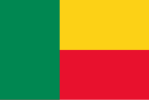

Benin

3

green, yellow, red

agree

3

The flag of Benin is correctly described by Gemini. It features three colors: green on the left vertical band, and yellow and red in horizontal bands on the right. No extra or missing colors are present.

agree

3

Gemini correctly identified all three colours on the flag of Benin: green, yellow, and red.

[figure not shown]

Bhutan

3

yellow, orange, white

agree

3

The flag of Bhutan is diagonally divided into two triangles: the upper triangle is yellow and the lower triangle is orange. The dragon in the center is white. Gemini correctly identified all three colours present: yellow, orange, and white. No extra or missing colours are reported.

agree

3

The flag of Bhutan consists of yellow and orange background triangles divided diagonally, with a white dragon featured prominently in the center. The fine black lines are merely structural outlines for the emblem details.

[figure not shown]

Bolivia

3

red, yellow, green

agree

3

The flag of Bolivia shown has three horizontal stripes: red on top, yellow in the middle, and green on the bottom. Gemini correctly identified all three colours. No colours are missing or invented.

agree

3

The flag shown is the civil tricolour of Bolivia, consisting of three equal horizontal bands of red, yellow, and green. Gemini's answer is completely accurate.

[figure not shown]

Bosnia and Herzegovina

3

blue, yellow, white

agree

3